Lake Name: Little Long Pond

Lake acreage: 18.36102314

County: SUFFOLK

PWLID: 1701-0353

Waterbody Classification: C

Coordinates: 40.9776,-72.296204

Is this waterbody a public water supply: No

Are there DOH desingated beaches on this waterbody: No

Open Water Indicators

2018 Sampling Results

Seasonal Change

06-02

06-17

07-01

07-15

07-28

08-18

09-03

09-23

Clarity (m)

2.10

4.15

2.90

2.45

3.45

2.65

2.60

3.60

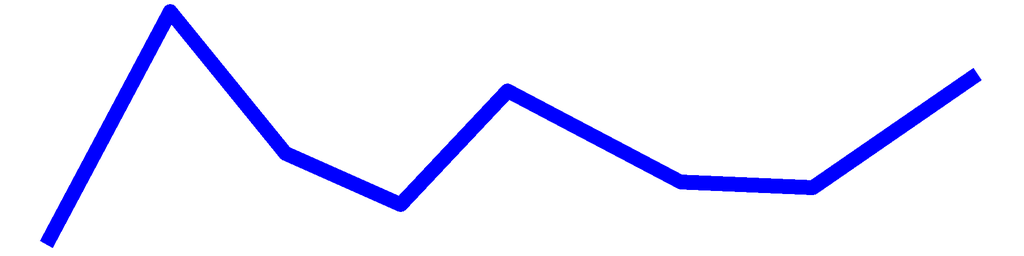

Surface TP (mg/L)

0.02

0.01

0.01

0.01

0.02

0.01

0.01

0.01

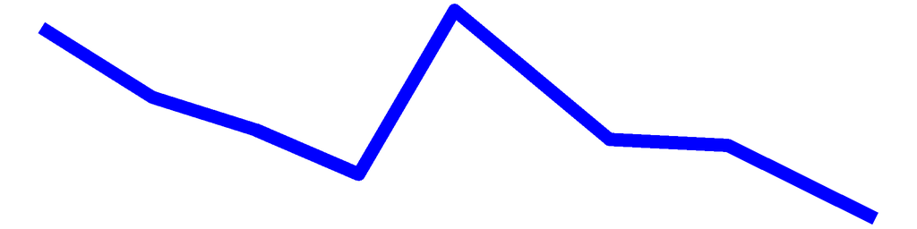

Surface TDP (mg/L)

0.01

0.00

0.00

0.01

0.00

0.01

0.00

0.01

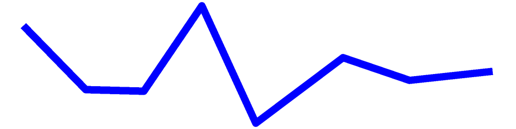

Deep TP (mg/L)

Deep TDP (mg/L)

TN (mg/L)

1.54

1.13

1.12

0.98

0.79

0.77

0.81

0.64

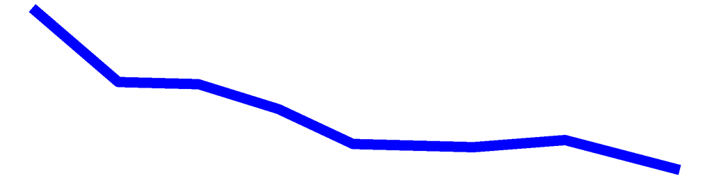

TDN (mg/L)

1.47

1.10

1.08

0.95

0.79

0.76

0.80

0.64

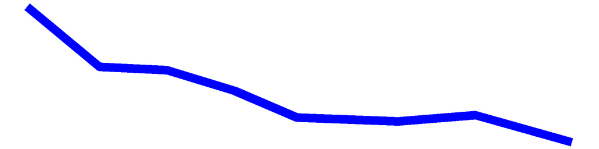

TN:TP

89.83

83.33

94.12

102.24

43.52

67.37

72.85

87.99

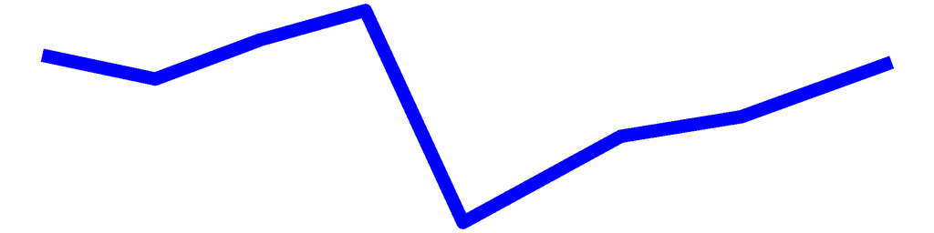

Surface NH3 (mg/L)

0.09

0.16

0.12

0.06

0.02

0.04

0.07

0.12

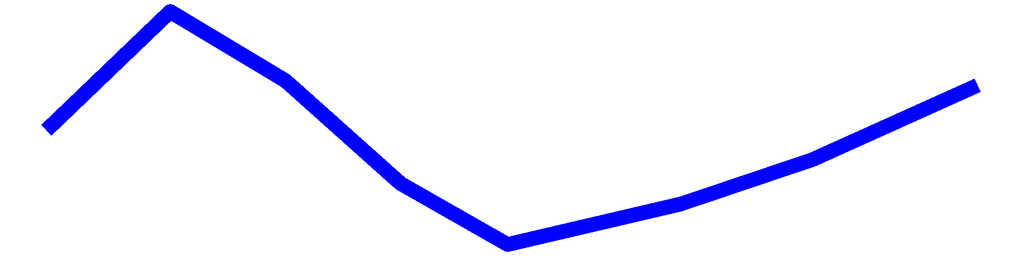

Deep NH3 (mg/L)

Chl.a (ug/L)

3.40

2.20

4.50

4.20

3.30

2.30

1.90

1.60

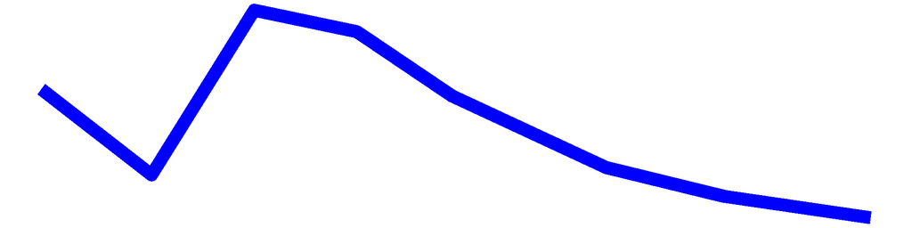

pH

7.96

7.45

7.67

7.21

7.67

8.31

7.46

7.39

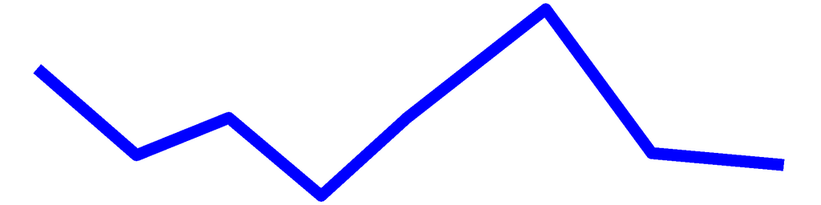

Cond (umho/cm)

158.70

197.30

149.80

152.00

148.70

165.70

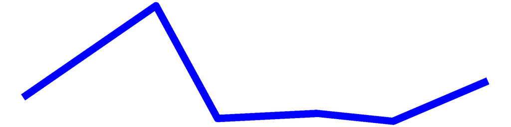

Surface Calcium (mg/L)

Bottom Calcium (mg/L)

Surface Chloride (mg/L)

24.60

24.50

Bottom Chloride (mg/L)

Upper Temp (degC)

25.00

24.00

29.00

28.00

29.00

29.00

27.00

20.00

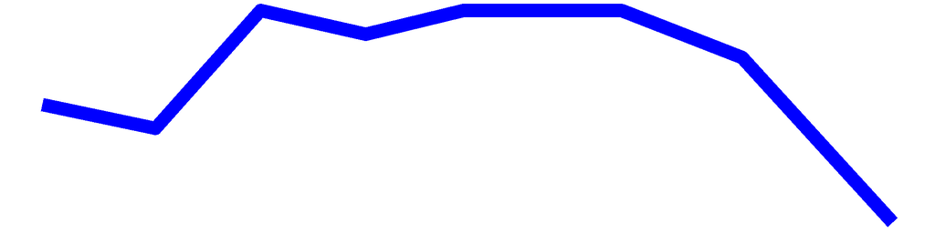

Deep Temp (degC)

FP BG Chl.a (ug/L)

8.72

0.00

12.74

7.82

7.12

4.84

4.67

2.00

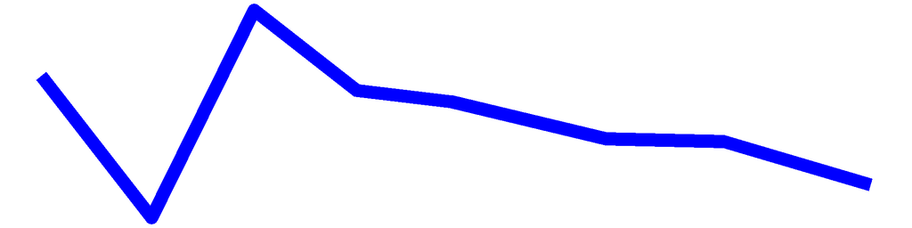

## Little Long Pond – Sampling Season Results

### HABs Status

#### Open Water Algae

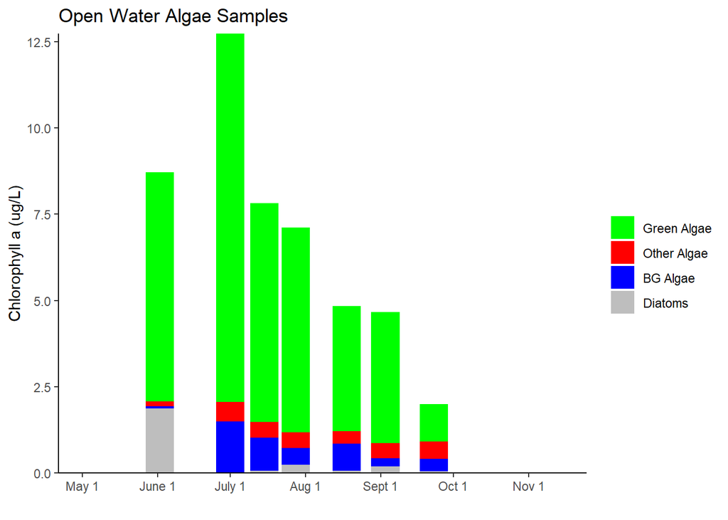

## Little Long Pond Long-Term Trend Analysis

#### Clarity

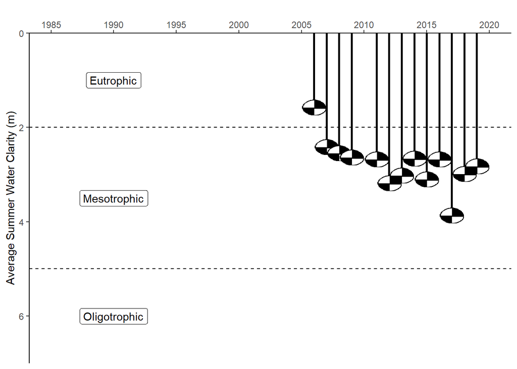

#### Chlorophyll *a*

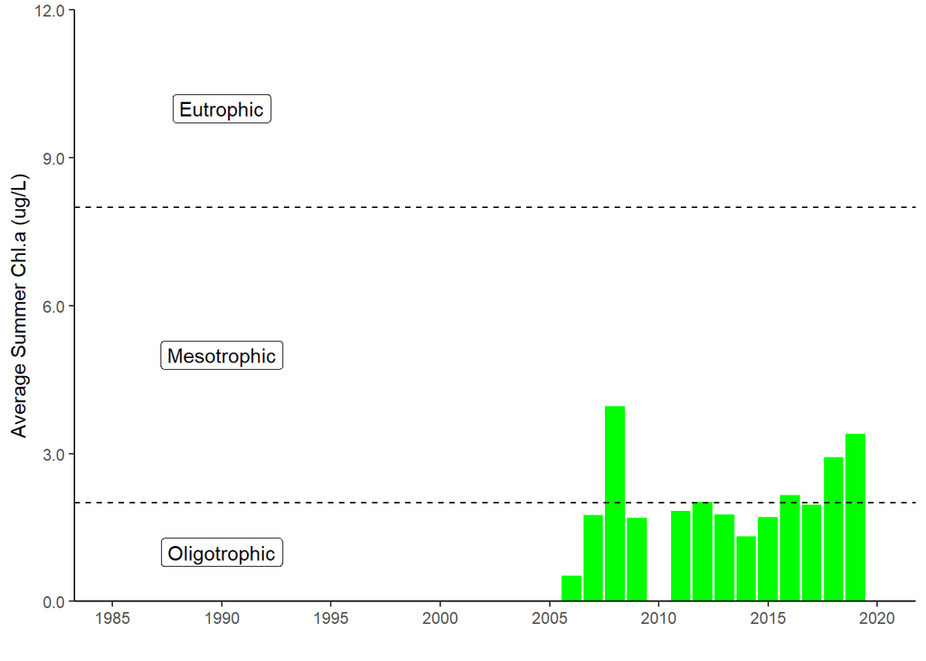

#### Surface and Deep Phosphorus

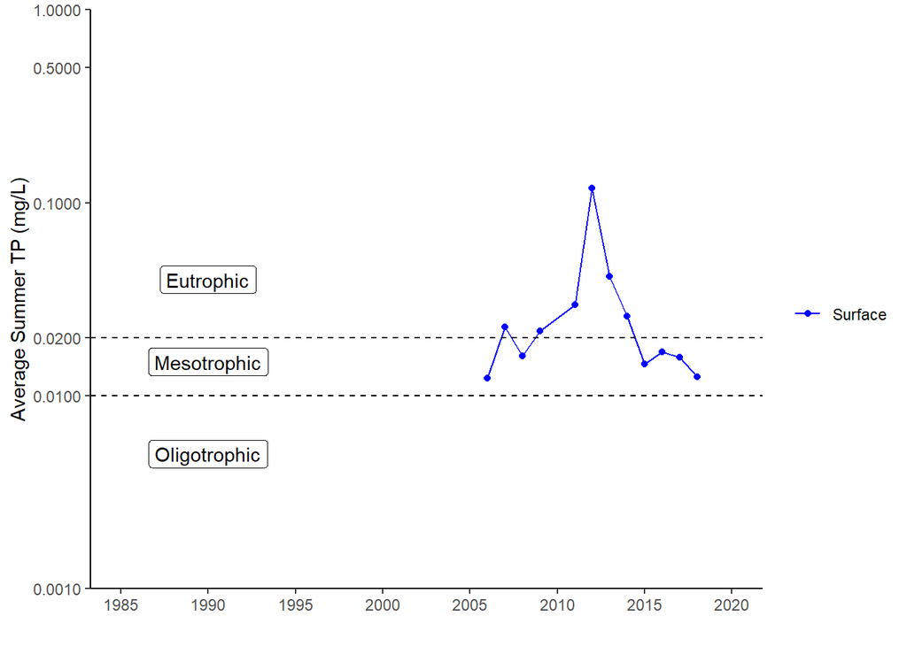

#### Nitrogen

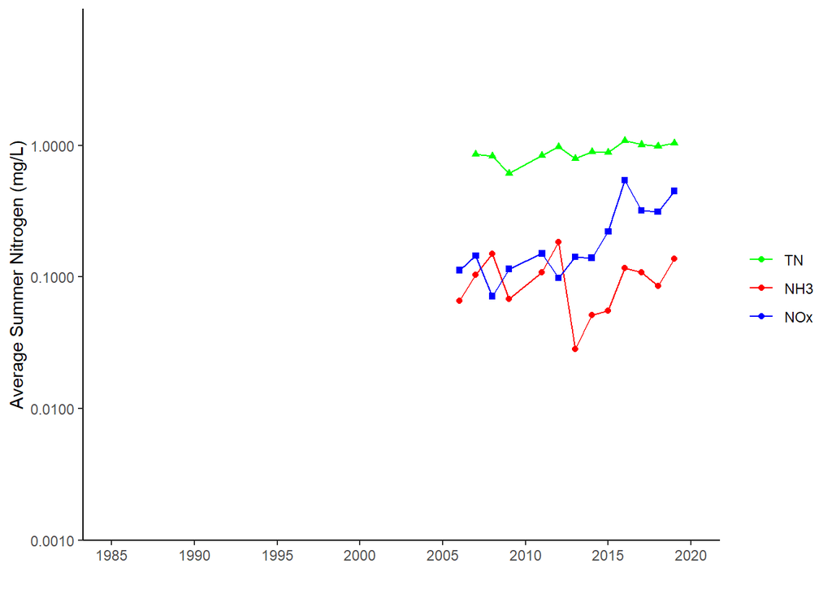

#### TN : TP

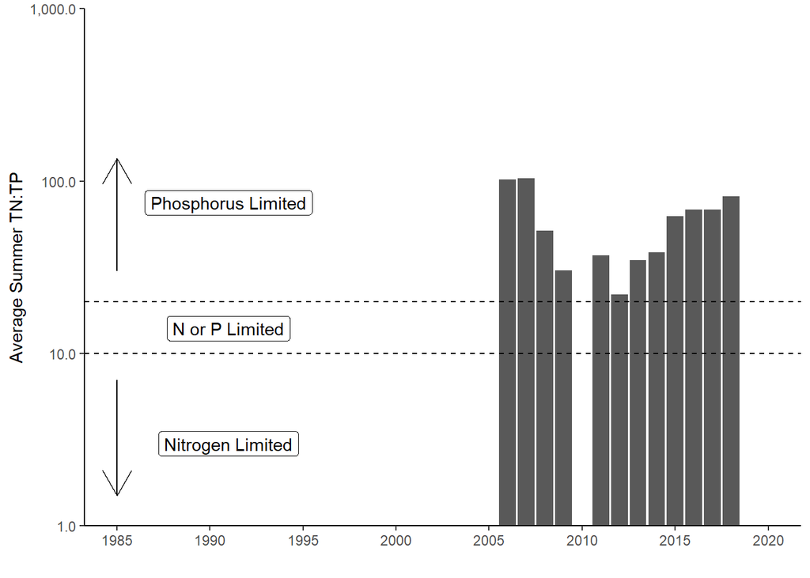

#### pH

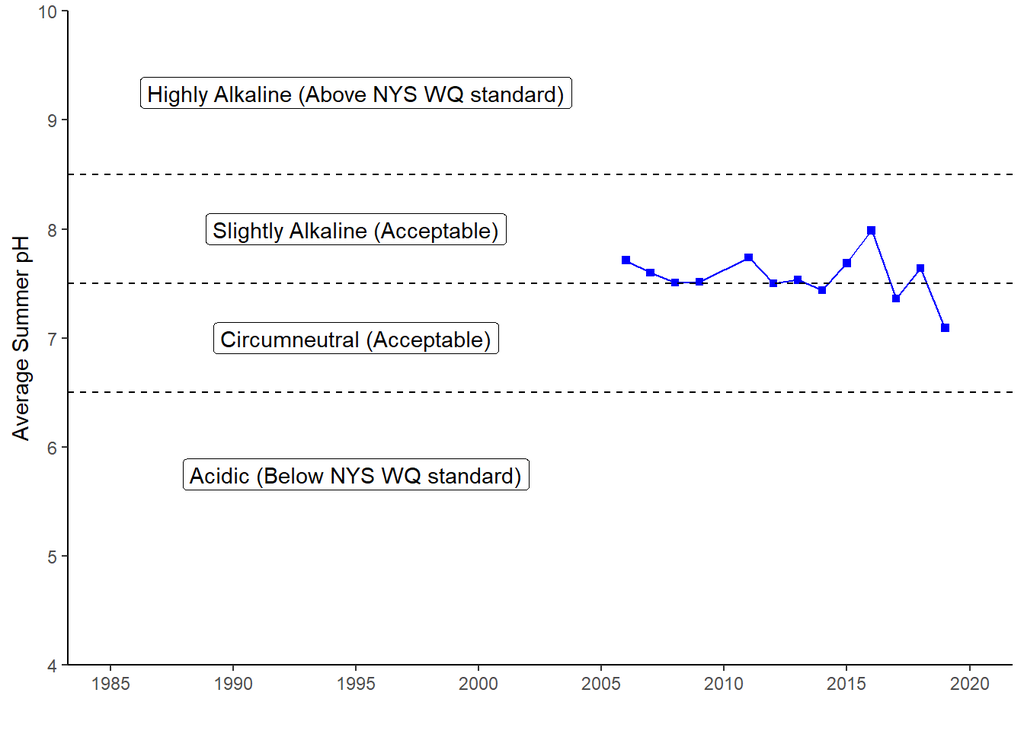

#### Specific Conductance

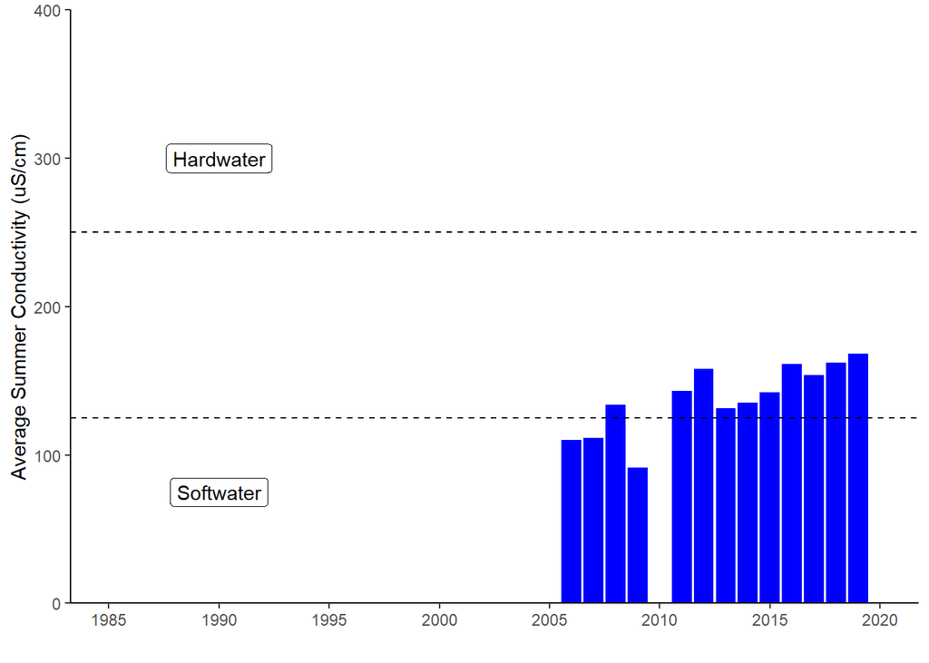

#### Calcium

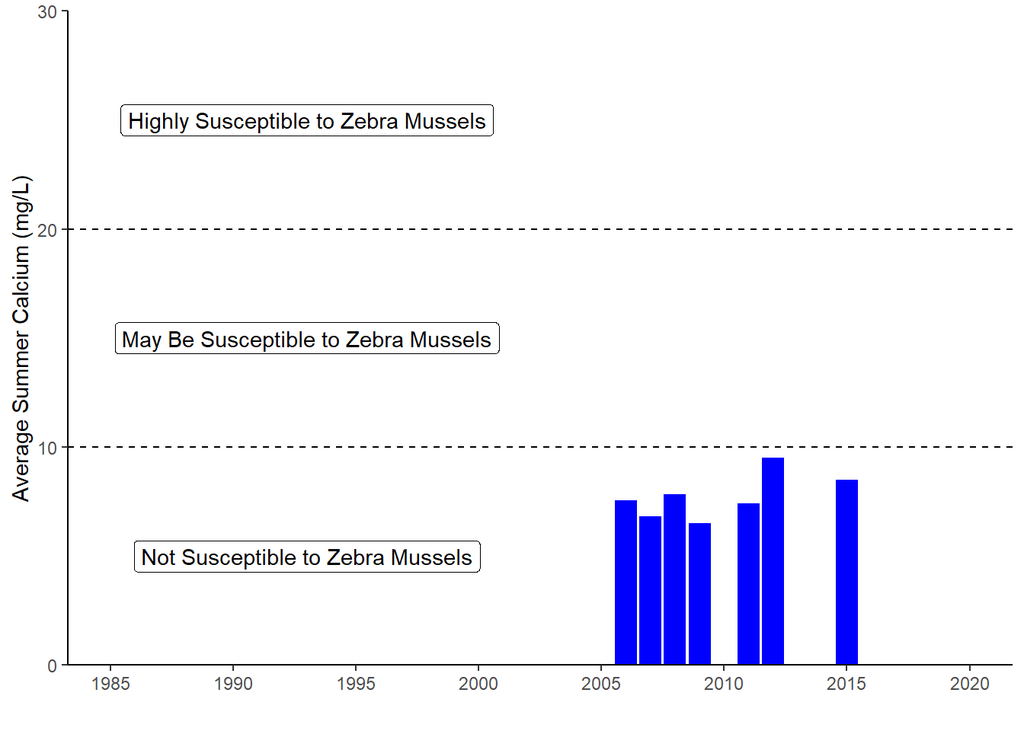

#### Chloride

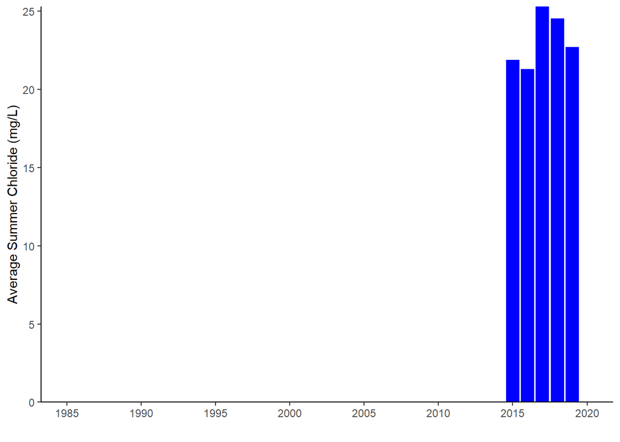

#### Color

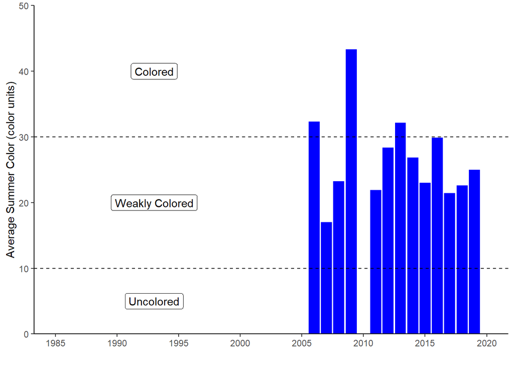

#### Surface and Deep Temperature

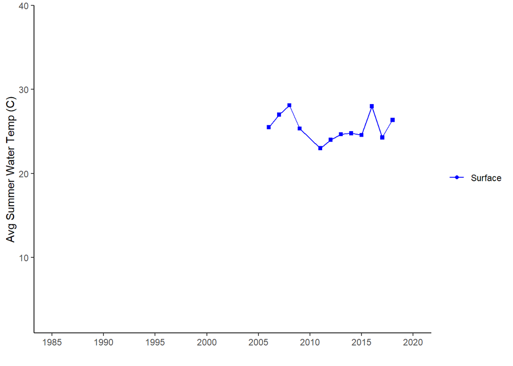

#### Lake Perception

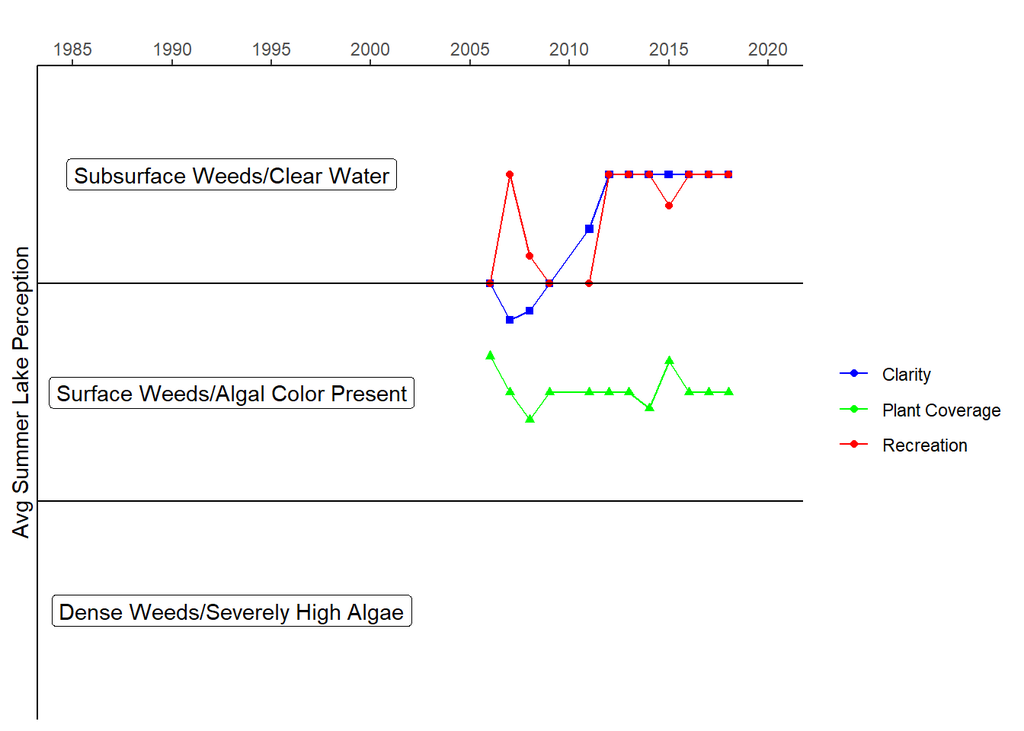

## Little Long Pond - In-Season Analysis

#### In Season Water Clarity

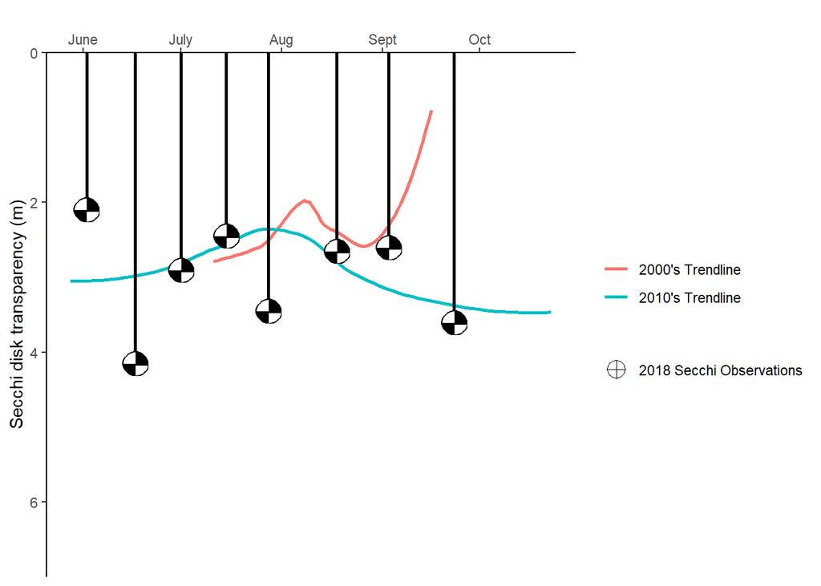

#### In Season Water Temperature

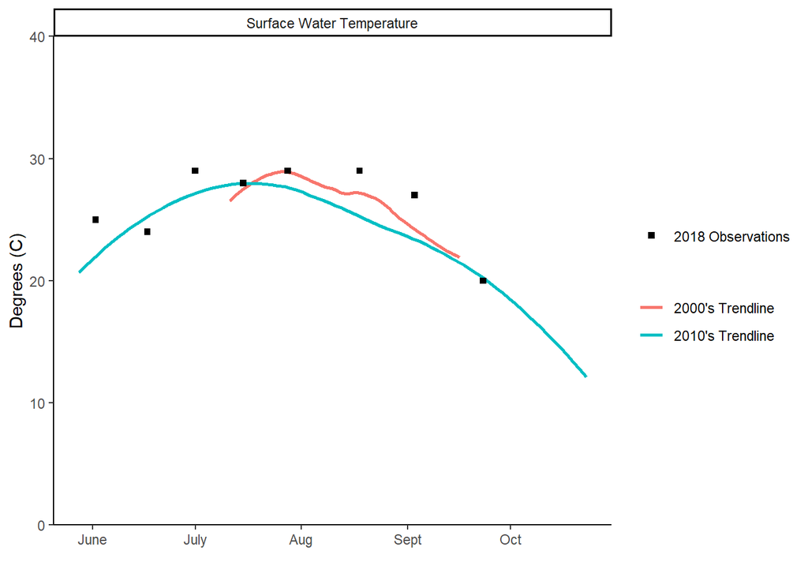